Author - 1826475

Date - 28/10/2020

### Introduction

This piece will focus on a little-known country on the eastern coast of Central America called **Belize**. To provide some context, the small country primarily hosts private enterprises such as agriculture but over recent years tourism has become an attractive sector. The massive Belize Barrier Reef and rich marine life are two standout natural features of Belize.

However, just like other countries around the world, tourism is a sector that is devastatingly hit, stealing local local jobs and incomes. Therefore, in this piece we will be diving into the data to look at how work spaces in the country have been affected as well as looking at the confirmed cases to give us a general outlook of the outbreak in the country. *(Note: Workplaces was chosen as the variable for analysis for its relation to Tourism)*

The data considered here is form the `tidycovid19` dataset which stores values for different variables concerning the Covid-19 pandemic for countries around the globe. For a more detailed description of the package and the variables contained please click [here](https://joachim-gassen.github.io/tidycovid19/).

### Reading in the raw data

Firstly, let’s read in th `tidycovid19` dataset:

```r
library(readxl)
CovidData <- read.csv("tidycovid19.csv")
```

### Processing the data

Next, we need to make sure R understands the `date` variable, which as the name suggests holds the date, correctly.

```r
library(lubridate)
CovidData$date = as.Date(parse_date_time(CovidData$date,orders=c("y","ym","ymd")))
```

The raw data has 49661 rows and 36 columns but, we aren’t always necessarily interested in the entire data. Hence, we tend to subset the data. We will select the data for the variables of interest which are:

- `date`: calendar date
- `confirmed`: Confirmed Covid-19 cases
- `gcmr_workplaces`: The frequency that people visit workplaces expressed as a percentage*100 change relative to the baseline period Jan 3 - Feb 6, 2020

The descriptions above are from this [link](https://joachim-gassen.github.io/tidycovid19/).

```r
library(dplyr)
Task1Data <- {CovidData %>%
    filter(country == "Belize" & (date > as.Date("2020-02-06")) & (date < as.Date("2020-09-19"))) %>%
    select(date, confirmed, gcmr_workplaces) }
```

This also gives a common range to evaluate over both variables over time. Next, we change `confirmed` from cumulative to holding cases per day:

```r
firstdiff <- function(x) {
  shifted <- c(0,x[1:(length(x)-1)])
  result = x-shifted
  which_negative = which(result<0)
  result[which_negative] = NA
  return(result)
}

Task1Data <- Task1Data %>%
  mutate(daily_confirmed = firstdiff(confirmed))
```

### Producing Plots

#### Confirmed cases per day plot

The plot below is for confirmed cases against time.

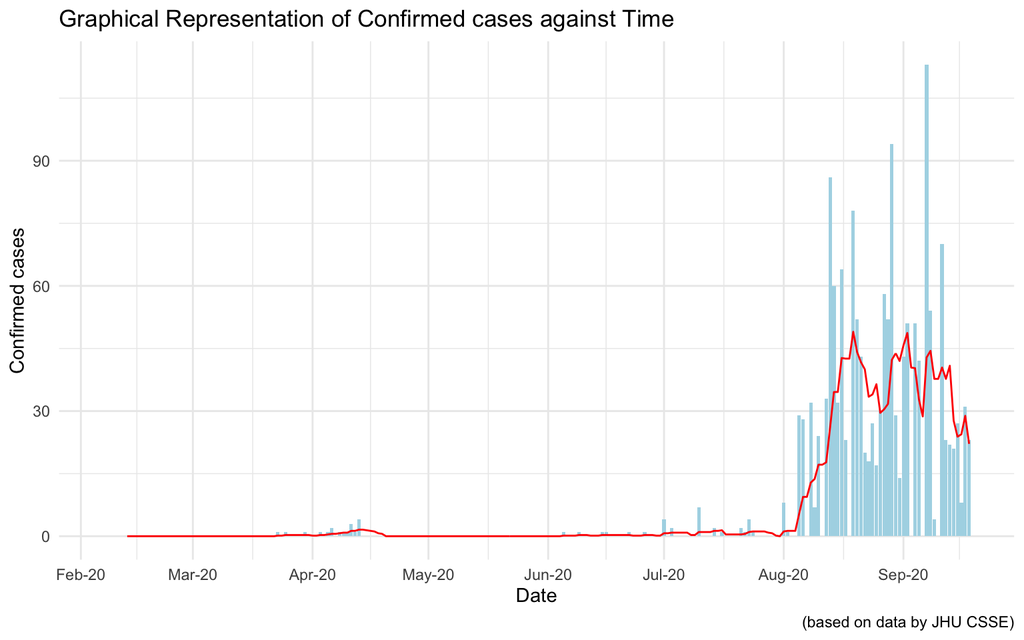

```r
library(ggplot2)
library(zoo)
ave_new_cases = rollmean(Task1Data$daily_confirmed, 7, na.pad=TRUE, align="right")
plotconfirmed.date <- {Task1Data %>% ggplot(aes(x = date))} + labs(title = "Graphical Representation of Confirmed cases against Time", x = "Date", y = "Confirmed cases", caption = "(based on data by JHU CSSE)") +
  geom_bar(aes(y = daily_confirmed), stat = "identity", fill = "lightblue") +
  geom_line(aes(y = ave_new_cases), color ="red") +
  theme_minimal()+
  scale_x_date(date_breaks = "months", date_labels = "%b-%y")
print(plotconfirmed.date)
```

### Workplace frequency plot

Now, we are going to plot work-place visits against time and evaluate the effect of total cases on the frequency of workplace visits.

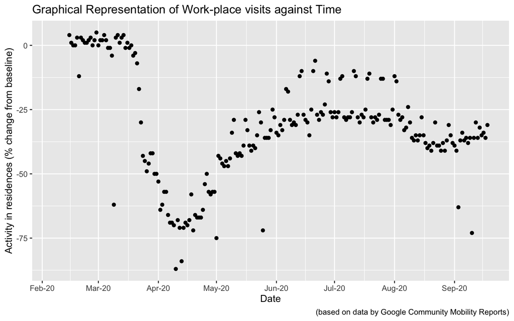

```r
library(ggplot2)

plotwork.date <- {Task1Data %>% ggplot(aes(x = date,
    y = gcmr_workplaces))} + geom_point() + labs(title = "Graphical Representation of Work-place visits against Time", x = "Date", y = "Activity in residences (% change from baseline)", caption = "(based on data by Google Community Mobility Reports)") +
    scale_x_date(date_breaks = "months", date_labels = "%b-%y")

print(plotwork.date)
```

The `tidycovid19` data used above is form the *Google Community Mobility Reports*. The data is collated using the **Location History** from mobile phones, which the report records a measurement of activity of the the frequency that people visit workplaces expressed as a percentage change for each day, relative to the baseline period Jan 3 - Feb 6, 2020. The plot above displays how the activity in work places changed in the Belize from Feb 15 - Sep 19 2020.